```python
from math import log, sqrt, exp
```

```python
from scipy.stats import norm, skew
```

```python
import pandas as pd
```

```python
import matplotlib.pyplot as plt
import numpy as np
```

# номер 1

# обсуждение результата в конце решения этой задачи

```python
print('начало данных:', pd.read_csv('RUBUSD_140101_200912.txt')['<DATE>'][0])
print('конец данных:', pd.read_csv('RUBUSD_140101_200912.txt')['<DATE>'].iloc[-1])

print('Данные по USD/RUB взяты с finam')
```

```
начало данных: 01/01/14
конец данных: 13/09/20
Данные по USD/RUB взяты с finam
```

```python
rub = pd.read_csv('RUBUSD_140101_200912.txt')['<CLOSE>'] #USD/RUB
ret = (rub/rub.shift(1)).fillna(0)
```

Тип payoff - heaviside function. В таком случае продукт состоит из встроенной облигации на 6 месяцев и бинарного опциона со страйком 0.95 от 1.

# Binary option pricing

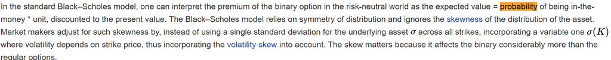

### Важное наблюдение

Наблюдаем, следующее из текста выше:

" The BS model relies on symmetry of distribution and ignores the skewness of the distribution of the asset "

Если я прав и идет речь о skenewss of returns, а не конкретно volatility skew. У наших ретернов skewness присутствует. Поэтому, при дальнейшей оценке опциона, стоит учитывать, что мы его можем, скорее всего, переоценивать (ибо при большем skewness у нас волатильность будет больше)

Мы все равно будем оценивать как есть, но это стоит учесть как одно из важных допущений, которые, почти с уверенностью нарушается

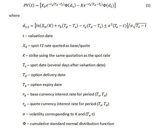

#### Текущее значение доходности 6-month treasury bill (source: https://ycharts.com/indicators/6_month_treasury_bill_rate)

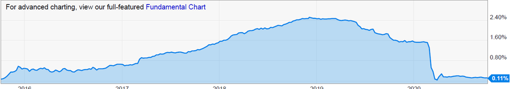

```python
S = 1 #current_price
K = 0.95 #ATM strike
v = (rub/rub.shift(1)).std()*sqrt(252)
r = 4.15/100 #interest rate (OFZ)
T = 0.5 #days remaining (annualized)
q = 0.11/100 #treasury 6month
d2 = (log(S/K) + (r - q + v**2 / 2) * T) / (v*sqrt(T))
option_price = exp(-r * T) * norm.cdf(-(d2 - v*sqrt(T)))
print(option_price)
```

```
0.28804678427197716
```

```python
def Option2(S, K, r, r_diff, v, t):
    d_2 = (log(S / K) + (r_diff - 0.5 * v ** 2) * t) / (v * (t ** 0.5))
    price = exp(-r * t) * norm.cdf(-d_2)
    return (price)
```

```python
Option2(S, K, r, r - q, v, T)
```

```
0.28804678427197716
```

```python
capital_gurantee_percent = 100/(1 + r/2)
print(capital_gurantee_percent)
```

```
97.96718099436688
```

```python
print('Требуется положить', capital_gurantee_percent, '% чтобы гарантировать 100%')
```

```
Требуется положить 97.96718099436688 % чтобы гарантировать 100%
```

```python
cap = (1- capital_gurantee_percent/100)*100
print('Дисконт:', cap,'%')
print('required return:', 5, '% = coupon({}%) + required_option_return({}%)'.format(0.01/2, (5 - 0.01)))
```

```
Дисконт: 2.032819005633113 %
required return: 5 % = coupon(0.005%) + required_option_return(4.99%)
```

```python
print('Требуется положить на опциональную часть: {}%'.format(((0.05-(0.01/2)*(1/100))*option_price)*100))
```

```
Требуется положить на опциональную часть: 1.4387936874385259%
```

```python
bond_price = capital_gurantee_percent # (in %)
opt_price = ((0.05-(0.01/2)*(1/100))*option_price)*100 # (in %)
price = bond_price + opt_price
print('price (в %) = ', bond_price + opt_price)
```

```
price (в %) =  99.4059746818054
```

```python
com = (1 - price/100)
print('Свободные средства (в процентах от капитала):', com , '%')
```

```
Свободные средства (в процентах от капитала): 0.005940253181945909 %
```

# Обсуждение результата

Заметим, что чем больше волатильность - тем больше цена опциона. Однако, как уже говорилось выше, скорее всего цена опциона завышается из-за нарушения некоторых предпосылок (присутствие ассимметрии) оценки с использованием БШ. По этой причине, кстати, вполне вероятно, что нам потребует положить меньше капитала на опциональную часть для достижения требуемой доходности.

Более того, мы также можем задать довольно интересный вопрос: какова вероятность того, что мы получим дополнительный доход?

Вопрос: завышается ли эта вероятность? Ответ: скорее всего. Опять, вспомним, что цена опциона скорее всего завышается из-за того, что наше распределение доходностей skewed (волитальность повышается).

Другой вопрос: сильно ли завышается вероятность? Ответ: зависит от того насколько сильно у нас skewness. Скорее да, так как в BS предполагается skewness = 0 (ибо нормальное распределние), то у нас (см. ячейку нижу). Я не могу оценить абсолютно - много ли это или нет (то есть, значительно ли это для модели или нет), но в сравнении с 0 - это, конечно, довольно большое значение, что гипотетически говорит о том, что мы сильно завышаем цену опциона

```python
print(skew(ret))
```

```
-34.06883012342298
```

```python
m = 125
hits = [rub[t:m+t].iloc[1]/rub[t:m+t].iloc[0] for t in range(len(rub[:-m]))]
hits = pd.Series(hits)
```

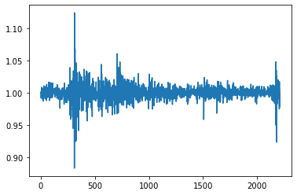

```python
plt.plot(hits)
```

```python
print('кол-во раз, когда цена USD/RUB за 6 месяцев опускалась ниже или равно 5%:', sum(hits <= 0.95))
print('всего промежутков скользящих окон:', len(hits))
```

```
кол-во раз, когда цена USD/RUB за 6 месяцев опускалась ниже или равно 5%: 8
всего промежутков скользящих окон: 2210
```

Позволив себе немного неформальности, я бы заявил, что доп. доход мы вряд ли получим. И даже если повезет и все же цена упадет ниже 5% - скорее всего это события сильно важные для этого рынка и довольно редкие (например, из графики видно, что это примерно 2 события за 6 лет) и в такие случаи 5% не будут очень солидно смотреться ;)

Итого: конкретно в нашем случае, используя наши методы и данные, мы получаем, что стоимость опциона завышается и вероятность получение дополнительного дохода скорее всего меньше. Рекомендовал бы ли я покупать данный структурный продукт? - На основании своих предположений и анализе - нет. Ещё учитвая коммиссии за этот продукт, можно попробовать поискать облигации с большей доходностью. В целом, класть деньги на дополнительный доход этого продукта - скорее gambling с маленькой отдачей и большой вероятностью OTM опциона.

Что в данном анализе стоит улучшить? Прайсинговую модель, чтобы лучше отражать стоимость опциона

# номер 2

Пейофф:

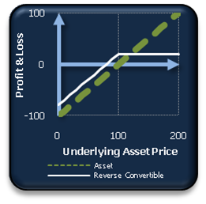

Тогда, reverse convertible состоит из short put и облигации

```python
def euro_vanilla_put(S, K, T, r, sigma):

    #S: spot price
    #K: strike price
    #T: time to maturity
    #r: interest rate
    #sigma: volatility of underlying asset

    d1 = (np.log(S / K) + (r + 0.5 * sigma ** 2) * T) / (sigma * np.sqrt(T))
    d2 = (np.log(S / K) + (r - 0.5 * sigma ** 2) * T) / (sigma * np.sqrt(T))

    put = (K * np.exp(-r * T) * norm.cdf(-d2, 0.0, 1.0) - S * norm.cdf(-d1, 0.0, 1.0))

    return put
```

```python
S = 1
K = 0.7
T = 3
vol = 0.3
r = 4.96/100
```

```python
premium = euro_vanilla_put(S, K, T, r, vol)
print("Премия:", premium)
```

```
Премия: 0.034659930078134255
```

```python
def calculate_bond_price(nominal, r, T, coupon):
    bond_price = 0
    bond_price +=  (nominal + coupon) / ((1 + r)**(T))

    return bond_price
```

```python
nominal = 1
```

```python
print('bond price for coupon: 0%:', calculate_bond_price(nominal, r, T,  0.001/100))
print('bond price for coupon: 0.001%:', calculate_bond_price(nominal, r, T,  0.001/100))
print('bond price for coupon: 0.01%:', calculate_bond_price(nominal, r, T,  0.01/100))
print('bond price for coupon: 1%:', calculate_bond_price(nominal, r, T,  1/100))
print('bond price for coupon: r%:', calculate_bond_price(nominal, r, T,  r))
```

```
bond price for coupon: 0%: 0.8648342424201386
bond price for coupon: 0.001%: 0.8648342424201386
bond price for coupon: 0.01%: 0.8649120767236133
bond price for coupon: 1%: 0.8734738501058389
bond price for coupon: r%: 0.9077209436347411
```

```python
coupon = 0.01 # in %
```

```python
bond_price = calculate_bond_price(1, r, T,  coupon/100)
```

```python
print('portfolio = long bond + short put')
print('price of portfolio (structued product):', bond_price - premium)
```

```
portfolio = long bond + short put
price of portfolio (structued product): 0.830252146645479
```

```python
print('portfolio return = return (long bond) + return (short put) = coupon + (bond nominal - price of bond) / price of bond + premium on short')
ret = coupon/100 + (nominal - bond_price)/bond_price + premium
print('return (3 years) =', ret)
```

```
portfolio return = return (long bond) + return (short put) = coupon + (bond nominal - price of bond) / price of bond + premium on short
return (3 years) = 0.19094681532560978
```

```python
print('годовая доходность:', (1+ret)**(1/3) - 1) # не в процентах
```

```
годовая доходность: 0.05997947489793187
```

# 3

Пейофф

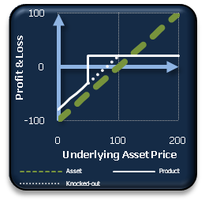

```python
# see R script for price calculation
```

```python
import csv
with open('price.txt', 'r') as fd:
    reader = csv.reader(fd)
    for row in reader:
        barrier_price = float(row[0].split(' ')[-1])
```

```python
premium = barrier_price
```

```python
premium
```

```
0.1203375
```

```python
coupon = 0.01
```

```python
print('portfolio return = return (long bond) + return (short put) = coupon + (bond nominal - price of bond) / price of bond + premium on short')
ret = coupon/100 + (nominal - bond_price)/bond_price + premium
print('return (3 years) =', ret)
```

```
portfolio return = return (long bond) + return (short put) = coupon + (bond nominal - price of bond) / price of bond + premium on short
return (3 years) = 0.2766243852474755
```

```python
print('годовая доходность:', (1+ret)**(1/3) - 1) # не в процентах
```

```
годовая доходность: 0.08481174510600664
```